# Exploratory Modelling with Bayesian Networks

Kaggle Titanic - Machine Learning from Disaster dataset

Author

Matthew Nimmo

Published

September 12, 2023

> Bayesian Networks are a statistical modelling technique that represents the joint probability between variables. Mixed networks allow modelling of discrete and continuous variables but require that continuous variables are Gaussian and have linear relationships. Neither of which can be gauranteed when performing exploratory modelling. However, despite this restriction the technique can be used for exploratory modeling to gain insight into the data. Later, in modeling the data, any potential non-Gaussian and non-linearity in the data can be accounted for by adding additional variables to the Bayesian Network (Gaussian Mixture Models are great for this). The Titanic dataset is used to showcase the use of Bayesian Networks to focus Exploratory Data Analysis (EDA) on key data features to speed up the analysis. An added bonus is that a Bayesian Network can be trained on data that contain missing values.

# Introduction

On April 10 1912 the newly constructed British luxury passenger liner, the RMS Titanic, departed on its maiden voyage from Southampton in the United Kingdom to New York in the United States of America. The liner first crossed the English channel to Cherbourg France then back to Queenstown in Ireland before heading across the Atlantic Ocean to New York on April 11 1912. Passengers boarded the ship at Southampton, Cherbourg and then Queenstown.

The Titanic never reached its destination.

On April 14 1912, four days after departure, an iceberg was spotted and then struck the Titanic. Approximately two and a half hours after hitting the iceberg, the Titanic sank coming to rest on the ocean seabed at around 3,800m below the ocean surface and approximately 600km south-southeast off the coast of Newfoundland.

Some passengers survived, some did not.

The Kaggle Titanic - Machine Learning from Disaster knowledge competition challenges us to find patterns in the provided data that may help us understand why some passengers survived and others did not. This simple analysis uses the Kaggle Titanic data and is aimed at using Bayesian Networks for exploratory modelling and rapid data understanding.

For this analysis, rather than treating the problem as a prediction problem, I will be treating it as a missing value problem. I will be focusing primarily on exploratory modelling using Bayesian Networks. The idea here is to try and minimize the amount of exploratory data analysis that is done by exploiting Bayesian Networks to zoom in on key data features. Only the important relationships will be explored.

Bayesian Networks assume that numeric variables are continuous and follow a Gaussian distribution and that the relationship between numeric variables are linear. However, a Bayesian Network can still model data with non-Gaussian numeric variables and non-linear relationships. This can be done by converting all variables to factors but at a cost of losing information. Or, alternatively, adding latent discrete variables that deal with the two constraints. In exploratory modelling I will initially ignore these constraints but will endeavor to account for them in later versions of the Bayesian Network model.

## Tools and techniques

The open source R environment for statistical computing was used (R Core Team 2023) along with the RStudio Integrated Development Environment and Quarto.

The R packages used for this analysis include `tidyverse` (Wickham et al. 2019) (data preparation and visualization), `bnlearn` (Scutari 2010) (training Bayesian Networks), `ggdag` (Barrett 2023) (visualization of directed acyclic graphs), `ggthemes` (Arnold 2021) (visualization plot themes), `ggmosaic` (Jeppson, Hofmann, and Cook 2021) (mosaic plots of cross tabular data), `patchwork` (Pedersen 2022) (composition of multiple ggplots), `SEMgraph` (Grassi, Palluzzi, and Tarantino 2023) (visualization of Bayesian Networks), `Amelia` (Honaker, King, and Blackwell 2011) (missing value plot), `RANN` (Arya et al. 2019) (fast nearest neighbour search), `targets` (Landau 2021) (pipelines), `knitr` (Xie 2023) (markdown functionality), and `quarto` (Allaire 2022) (interface to the Quarto).

The `targets` R package is used to manage the data analytics pipeline. For convenience, the R code used to generate target objects (data or visuals or models) is included in this Quarto markdown report. It is usually better to have all the R code in separate R files (stored in a ./src folder) and included in the `targets` pipeline and the markdown report only including calls to load the artefacts (including plots).

Additional convenience functions were used for reducing code duplication when plotting Bayesian Networks (`plot_bn`) and for adding percentage labels to mosaic plots (`add_percent_label`).

````markdown
```{r}
#| file: src/exploratory-modelling/plot_bn.R
plot_bn <- function(m, dag.layout="gem") {
  g <- as.igraph(m) %>%
    graph2dagitty() %>%
    tidy_dagitty(layout = dag.layout,
                 seed = 2022)
  g <- g %>%
    ggplot(aes(x = x,
               y = y,
               xend = xend,
               yend = yend)) +
    geom_dag_edges(aes(start_cap = ggraph::circle(4, "mm"),
                       end_cap = ggraph::circle(4, "mm")),
                   edge_colour = "grey70",
                   edge_width = 0.2) +
    geom_dag_text(colour = "black",
                  size = 4) +
    theme_dag() +
    theme(plot.margin = unit(c(0.1, 0.1, 0.1, 0.1), "cm"))

  return(g)
}
```
````

````markdown
```{r}
#| file: src/exploratory-modelling/add_percent_label.R
add_percent_label <- function(p) {
  pd <- ggplot_build(p)$data %>%
    as.data.frame() %>%
    filter(.wt > 0)

  pn <- names(pd)[grepl("x__[^fill]", names(pd))]
  pd$group <- pd[[pn]]

  pd <- pd %>%
    group_by(group) %>%
    mutate(percentage = paste0(round(100 * .wt / sum(.wt), 1), "%"))

  p + geom_label(data = pd,
                 aes(x = (xmin + xmax) / 2,
                     y = (ymin + ymax) / 2,
                     label = percentage),
                 size = 2.5)
}
```
````

Set the `targets` package options. The required packages used by the functions in the pipeline are `dplyr`, `readr`, and `bnlearn`

To perform a clean build use the functions `tar_unscript` and `tar_prune`.

````markdown
```{r}
#| eval: false

# Clean build.
tar_unscript()
tar_prune()
```
````

# The Titanic dataset

The Kaggle Titanic competition dataset consists of two separate comma delimited (CSV) data files - train.csv and test.csv. Both data files were loaded and combined into a single data frame. The variable names were converted to lower case.

## Load the data

Import the train.csv data.

````markdown
```{targets a_titanic_train}
#| label: a_titanic_train
#| tar_simple: true
#| tar_interactive: false
#| output: false

tar_target(a_titanic_train, {
  df <- read_csv("./data/train.csv")
  df <- as.data.frame(df, stringsAsFactors=FALSE)
  names(df) <- tolower(names(df))
  df
})
```
````

Import the test.csv data.

````markdown
```{targets a_titanic_test}
#| label: a_titanic_test
#| tar_simple: true
#| tar_interactive: false
#| output: false

tar_target(a_titanic_test, {
  df <- read_csv("./data/test.csv")
  df <- as.data.frame(df, stringsAsFactors=FALSE)
  names(df) <- tolower(names(df))
  df
})
```
````

Combine the test and train data into a single data frame (a_titanic)

````markdown
```{targets a_titanic}
#| label: a_titanic
#| tar_simple: true
#| tar_interactive: false
#| output: false

tar_target(a_titanic, {
  df <- bind_rows(a_titanic_train,
                  a_titanic_test)
  df
})
```
````

Build the data and then load `a_titanic` data frame into memory.

When using `targets` within markdown documents we need to run the `tar_make` function to build the target object and `tar_load` to load the object into memory before the object can be used in the markdown. We do this after every `targets` code block.

````markdown
```{r}
#| output: false
#| message: false
#| error: false
if (length(tar_outdated()) > 0) {
  tar_make()
}
tar_load(a_titanic)
```
````

## Description of the data

The data contains 12 variables of which 7 (passengerid, survived, pclass, age, sibsp, parch, and fare) are numeric and 5 (name, sex, ticket, cabin, and embarked) are discrete character variables. The passengerid variable is not relevant for data analysis and modelling as it is just a row identification number. Of the numeric variables only two, fare and age, appear to be continuous while survived is a binary variable, sibsp and parch are count variables, and pclass a factor.

````markdown
```{r}
str(a_titanic)
```
````

```
'data.frame':   1309 obs. of  12 variables:
 $ passengerid: num  1 2 3 4 5 6 7 8 9 10 ...
 $ survived   : num  0 1 1 1 0 0 0 0 1 1 ...
 $ pclass     : num  3 1 3 1 3 3 1 3 3 2 ...
 $ name       : chr  "Braund, Mr. Owen Harris" "Cumings, Mrs. John Bradley (Florence Briggs Thayer)" "Heikkinen, Miss. Laina" "Futrelle, Mrs. Jacques Heath (Lily May Peel)" ...
 $ sex        : chr  "male" "female" "female" "female" ...
 $ age        : num  22 38 26 35 35 NA 54 2 27 14 ...
 $ sibsp      : num  1 1 0 1 0 0 0 3 0 1 ...
 $ parch      : num  0 0 0 0 0 0 0 1 2 0 ...
 $ ticket     : chr  "A/5 21171" "PC 17599" "STON/O2. 3101282" "113803" ...
 $ fare       : num  7.25 71.28 7.92 53.1 8.05 ...
 $ cabin      : chr  NA "C85" NA "C123" ...
 $ embarked   : chr  "S" "C" "S" "S" ...
```

The variable fare contains a value of zero - this suggests that the passenger had a free ticket. What does a value of 0 for fare represent? These values are assumed, for the moment, to be invalid and are therefore replaced with a missing value.

````markdown
```{r}
summary(a_titanic)
```
````

```
  passengerid      survived          pclass          name
 Min.   :   1   Min.   :0.0000   Min.   :1.000   Length:1309
 1st Qu.: 328   1st Qu.:0.0000   1st Qu.:2.000   Class :character
 Median : 655   Median :0.0000   Median :3.000   Mode  :character
 Mean   : 655   Mean   :0.3838   Mean   :2.295
 3rd Qu.: 982   3rd Qu.:1.0000   3rd Qu.:3.000
 Max.   :1309   Max.   :1.0000   Max.   :3.000
                NA's   :418
     sex                 age            sibsp            parch
 Length:1309        Min.   : 0.17   Min.   :0.0000   Min.   :0.000
 Class :character   1st Qu.:21.00   1st Qu.:0.0000   1st Qu.:0.000
 Mode  :character   Median :28.00   Median :0.0000   Median :0.000
                    Mean   :29.88   Mean   :0.4989   Mean   :0.385
                    3rd Qu.:39.00   3rd Qu.:1.0000   3rd Qu.:0.000
                    Max.   :80.00   Max.   :8.0000   Max.   :9.000
                    NA's   :263
    ticket               fare            cabin             embarked
 Length:1309        Min.   :  0.000   Length:1309        Length:1309
 Class :character   1st Qu.:  7.896   Class :character   Class :character
 Mode  :character   Median : 14.454   Mode  :character   Mode  :character
                    Mean   : 33.295
                    3rd Qu.: 31.275
                    Max.   :512.329
                    NA's   :1
```

The variable pclass contains the unique values: 3, 1, and 2.

The variable sibsp contains the unique values: 1, 0, 3, 4, 2, 5, and 8.

The variable parch contains the unique values: 0, 1, 2, 5, 3, 4, 6, and 9.

The variable embarked contains the unique values: S, C, Q, and NA.

The variable cabin contains 187 values.

````markdown
```{r}
#| eval: false
unique(a_titanic$cabin)
```
````

The cabin variable is a composite of deck and room number. For some passengers cabin is a list of more than one deck and room number (minimum=1; maximum=4). For these passengers, the list of cabins is assumed to be for groups of passengers that are travelling on the same ticket but are split across multiple cabins.

The name variable is a composite of surname, title, first name, [middle name]. The variable surname maybe of use to identify family members who will be in close proximity to each other and will likely move as a group during the event. It is hypothesized that family group and possibly group size may be a factor in predicting survival. It is likely that family name will not be unique. First name and middle name are assumed to have no relationship with survival - why should it? However, title may be of use as it is an identifier of seniority (age) and sex.

The combined data contain 11% missing values (Figure 1). Majority of the missing values are found in the cabin (and deck), survived, and age variables. A small number of missing values are found in fare (including replaced 0 values) and embarked. It is likely that age could be imputed using a persons title while embarked, deck, and fare could be imputed using ticket.

Figure 1: Map of the missing values in the Titanic dataset.

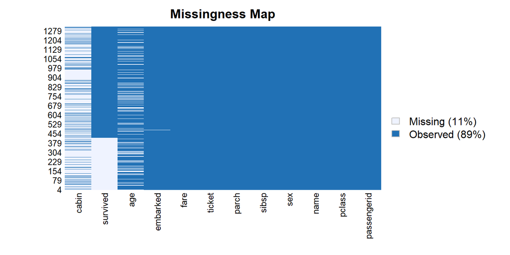

````markdown
```{r}
#| fig.width: 8
#| fig.height: 4
#| label: fig-missing
#| fig-cap: "Map of the missing values in the Titanic dataset."
Amelia::missmap(a_titanic,
                main = "Missingness Map")
```
````

## Initial data preparation

````markdown
```{targets b_titanic}
#| label: b_titanic
#| tar_simple: true
#| tar_interactive: false
#| output: false

tar_target(b_titanic, {
  df <- a_titanic

  df$title <- sapply(df$name,
                     \(n) regmatches(n, regexpr("([A-Za-z]+)[.]", n)))
  df$title <- gsub("[.]", "", df$title)

  df$deck <- df$cabin
  df$deck <- gsub("[[:digit:]].*", "", df$deck)
  df$deck <- gsub(". ", "", df$deck)

  df$fare <- ifelse(!is.na(df$fare) & df$fare == 0, NA, df$fare)

  df$age_class <- cut(df$age,
                      breaks = c(0,1,5,16,40,60,100),
                      labels = c("baby","infant","child","young adult",
                                 "middle-aged adult","old adult"))
  df$embarked <- factor(df$embarked,
                        levels = c("S","C","Q"),
                        labels = c("Southampton","Cherbourg","Queenstown"))
  df$sex <- factor(df$sex)
  df$deck <- factor(df$deck)
  df$title <- factor(df$title)
  df$survived <- factor(df$survived,
                        levels = c(0,1),
                        labels = c("No","Yes"))
  #df$sibsp <- factor(df$sibsp)
  #df$parch <- factor(df$parch)

  df
})
```
````

Build the `b_titanic` data frame and then load into memory.

````markdown
```{r}
#| output: false
#| message: false
#| error: false
if (length(tar_outdated()) > 0) {
  tar_make()
}
tar_load(b_titanic)
```
````

# Exploratory Modelling and Analysis

## Initial Bayesian Network trained on the pre-processed Titanic data

The observed variables survived, pclass, sex, age, sibsp, parch, embarked, and fare were included in exploratory modelling using Bayesian Networks. The variable passengerid was excluded as this variable only identifies the passenger data (row) which is required for generating the submission file. The variables name and cabin are composite variables and have been excluded. However, two additional variables title and deck were constructed from name and cabin respectively and were included.

To gain insight into the missing value mechanism, additional indicator variables were added to the data identifying missing values.

````markdown
```{targets titanic_bn0}
#| label: titanic_bn0
#| tar_simple: true
#| tar_interactive: false
#| output: false

tar_target(titanic_bn0, {
  flds <- c("survived","title","sex","age","sibsp","parch",
            "embarked","deck","fare","pclass")
  x <- b_titanic[, flds]
  x[] <- ifelse(is.na(x), 1, 0)
  names(x) <- paste("missing", names(x), sep=".")
  x <- cbind(b_titanic[, flds], x)
  bn <- structural.em(x,
                      maximize.args = list(whitelist=NULL, blacklist=NULL),
                      return.all = TRUE,
                      impute = "parents")

  bn
})
```
````

Build the initial Bayesian Network `titanic_bn0` and load into memory.

````markdown
```{r}
#| output: false
#| message: false
#| error: false
if (length(tar_outdated()) > 0) {
  tar_make()
}
tar_load(titanic_bn0)
```
````

From the Bayesian Network trained with missing value variables included, the missing values for deck, age, and fare are missing at random (Figure 2). Missing values for deck are dependent on survived, embarked, fare, and pclass. Missing values for age are dependent on embarked, pclass, and missing.fare. And missing values for fare are dependent on survived.

Figure 2: Initial Bayesian Network with missing value variables.

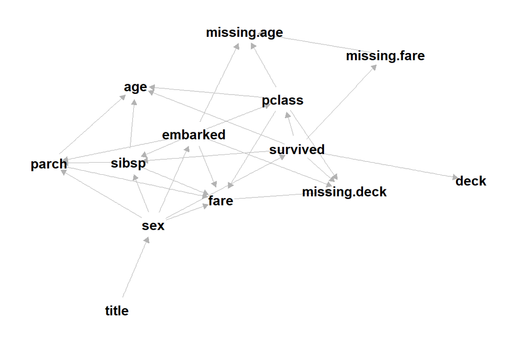

````markdown
```{r}
#| fig.width: 6
#| fig.height: 4
#| label: fig-bn0
#| fig-cap: "Initial Bayesian Network with missing value variables."
plot_bn(titanic_bn0$fitted, dag.layout="kk")
```
````

````markdown
```{targets titanic_bn1}
#| label: titanic_bn1
#| tar_simple: true
#| tar_interactive: false
#| output: false

tar_target(titanic_bn1, {
  flds <- c("survived","title","sex","age","sibsp","parch",
            "embarked","deck","fare","pclass")
  x <- b_titanic[, flds]
  bn <- structural.em(x,
                      maximize.args = list(whitelist=NULL, blacklist=NULL),
                      return.all = TRUE,
                      impute = "parents")

  bn
})
```
````

Build the Bayesian Network `titanic_bn1` without the missing value variables and load into memory.

````markdown
```{r}
#| output: false
#| message: false
#| error: false
if (length(tar_outdated()) > 0) {
  tar_make()
}
tar_load(titanic_bn1)
```
````

The retrained Bayesian Network (without the missing value variables) suggests surviving the sinking of the Titanic depends on age, sex, pclass, sibsp, and deck (Figure 3). The direction of the edges are ignored for now.

Interestingly, deck is not connected to fare or pclass in the Bayesian Network but is linked to survival. It is expected that top decks would be occupied by first class passengers and the lowest decks occupied by third class passengers with the top decks being more expensive than the lower decks. This lack of correlation is likely the result of the large number of missing values in deck and bias in the data. Further processing of the ticket variable could be used to impute some or all of the missing values for deck and fare.

Survival based on what deck you were on is likely the result of crowding during muster. Top decks being closer to the lifeboats would likely result in passengers in cabins on the top decks being at the front of the queue and more likely to get on one of the few lifeboats available. Passengers on the lower decks, third class passengers, would likely be at the back of the queue and likely be stuck on stairs and in corridors inside the cruise liner making it difficult to get to a lifeboat.

The connection between age and pclass is interesting and likely reflects that older passengers are likely to be wealthier and more likely to pay for a better cabin in first or second class. The connection between embarked with sex, and pclass is likely coincidental and could be and indicator of bias in the data. The connection between sex and fare is interesting - do females with children pay more than male passengers without children? Unexpectedly, the variable title is only connected to sex and not connected to age.

Figure 3: Initial Bayesian Network.

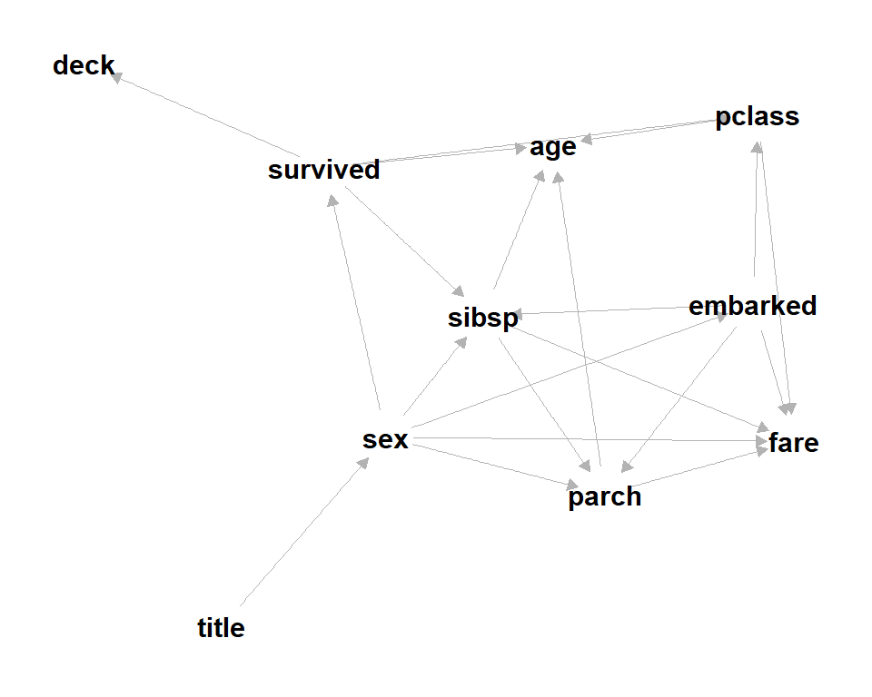

````markdown
```{r}
#| fig.width: 5
#| fig.height: 4
#| label: fig-bn1
#| fig-cap: "Initial Bayesian Network."
plot_bn(titanic_bn1$fitted)
```
````

## Visual exploratory analysis

Male passengers had a very low chance of survival while females had a very high chance of survival (Figure 4).

Figure 4: Mosaic plot of survived by sex (Titanic dataset).

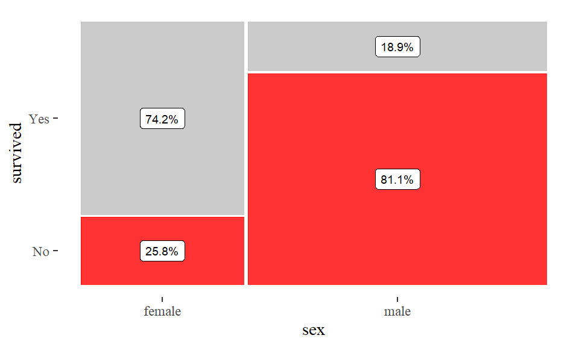

````markdown
```{r}
#| fig.width: 5
#| fig.height: 3
#| label: fig-mosaic1
#| fig-cap: "Mosaic plot of survived by sex (Titanic dataset)."
#| message: false

p <- b_titanic %>%
  filter(!is.na(survived) & !is.na(sex)) %>%
  ggplot() +
  geom_mosaic(aes(x = product(survived, sex),
                  filled = survived)) +
  scale_fill_manual("legend",
                    values = c("No" = "red",
                               "Yes" = "grey")) +
  theme_tufte()
add_percent_label(p)
```
````

````markdown
```{r}
#| eval: false
#| label: tbl-xtab1
#| tbl-cap: "Cross table counts of sex by survival."
table(b_titanic$sex, b_titanic$survived)
```
````

The box plot of age by title (extracted from name), clearly shows a strong relationship between age and title (Figure 5). Because of this strong relationship, the connection between title and age will be enforced using a white-list when training the initial Bayesian Network. Title is also strongly related to sex except for the title Dr where it can refer to either a male or female.

Figure 5: Box plot of age by title (Titanic dataset).

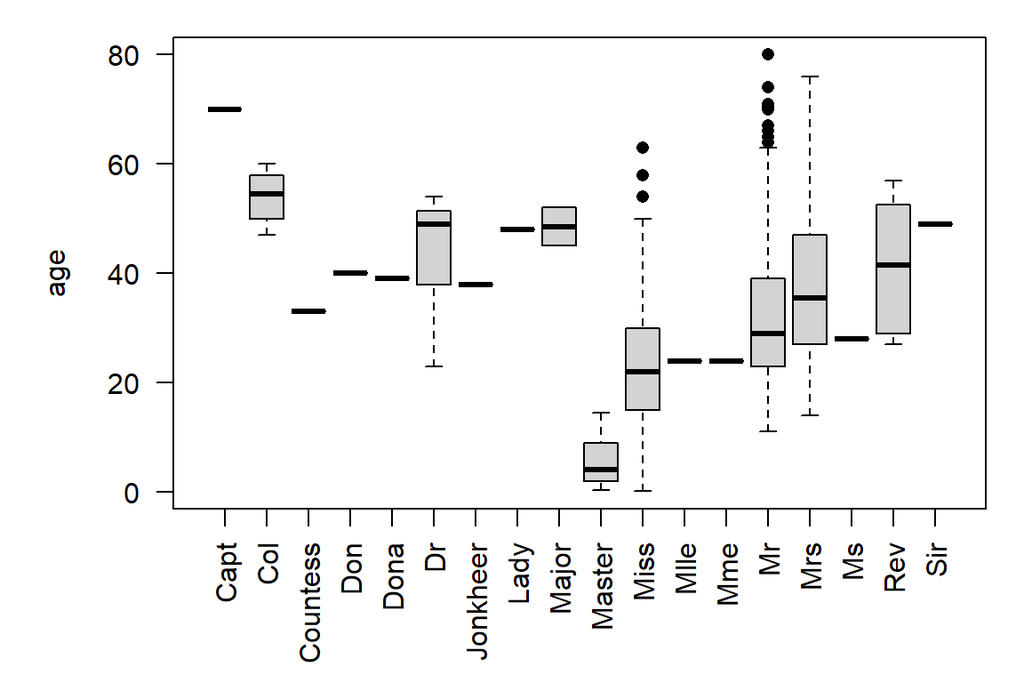

````markdown
```{r}
#| fig.width: 6
#| fig.height: 4
#| label: fig-box1
#| fig-cap: "Box plot of age by title (Titanic dataset)."

par(mar=c(5.1,5.1,1.1,1.1))
boxplot(age ~ title,
        data = b_titanic,
        horizontal = FALSE,
        las = 2,
        pch = 16,
        xlab = "")
```
````

````markdown
```{r}
#| eval: false
#| label: tbl-xtab2
#| tbl-cap: "Cross table counts of sex by Title."
table(b_titanic$sex, b_titanic$title)
```
````

Passengers in the 15 to 40 age group are more likely to have a sibsp of less than 4 and parch less than 3 while passengers aged over 40 are more likely to have 3 or more parch (Figure 6). First class passengers are likely to be older adults (median age of around 40), while third class passengers are younger adults (median age of around 25).

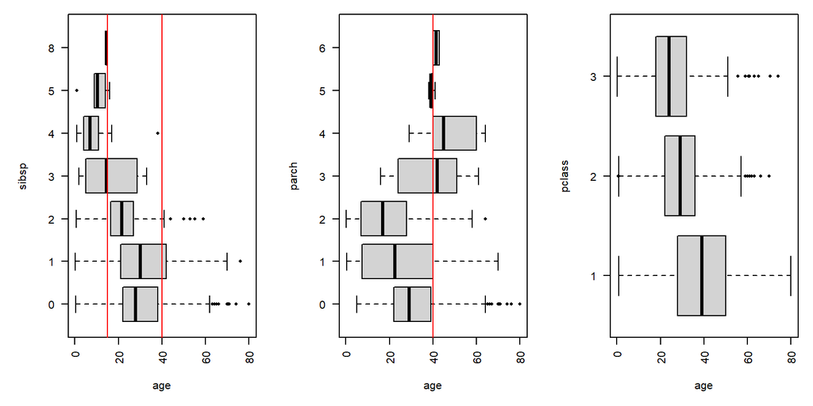

````markdown
```{r}
#| fig.width: 8
#| fig.height: 4
#| label: fig-box2
#| fig-cap: "Box plot of sibsp, parch, and pclass by sex (Titanic dataset)."

par(mfcol=c(1,3), mar=c(5.1,5.1,1.1,1.1))

boxplot(age ~ sibsp,
        data = b_titanic,
        horizontal = TRUE,
        las = 2,
        pch = 16)
abline(v = c(15,40),
       col = "red")

boxplot(age ~ parch,
        data = b_titanic,
        horizontal = TRUE,
        las = 2,
        pch = 16)
abline(v = 40,
       col = "red")

boxplot(age ~ pclass,
        data = b_titanic,
        horizontal = TRUE,
        las = 2,
        pch = 16)
```
````

Plotting survived (cumulative) by age highlights five distinct age groups with different rates of survival (Figure 7). Ages between 0 to 6 (baby, infant) and 15 to 40 (adolescent, young adult) have the highest rates of survival. Being older than 60 (elderly) has a very low chance of survival. Chances of survival decrease with increasing age above 40.

Figure 7: Cumulative plot of survived by age (Titanic dataset).

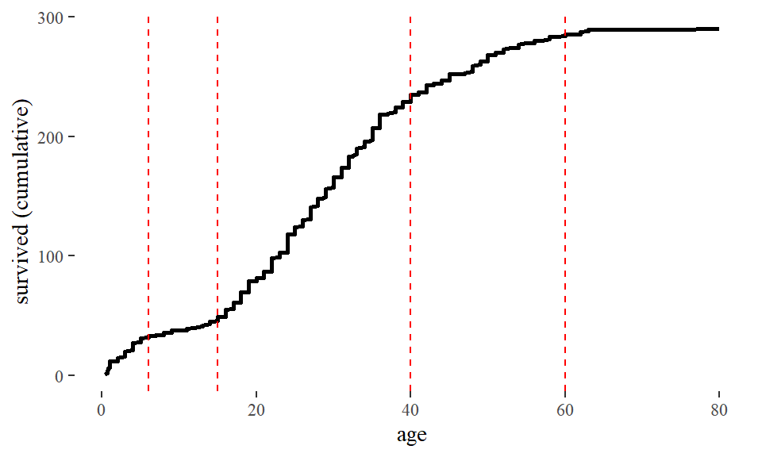

````markdown
```{r}
#| fig.width: 5
#| fig.height: 3
#| label: fig-line1
#| fig-cap: "Cumulative plot of survived by age (Titanic dataset)."

x <- b_titanic %>%
  filter(!is.na(survived) & !is.na(age)) %>%
  arrange(age) %>%
  mutate(survived = ifelse(survived == "Yes", 1, 0)) %>%
  mutate(survived = cumsum(survived))
ggplot(x,
       aes(x = age,
           y = survived)) +
  geom_line(linewidth = 1) +
  geom_vline(xintercept = c(6,15,40,60),
             linetype = "dashed",
             colour = "red") +
  ylab("survived (cumulative)") +
  theme_tufte()
```
````

Chances for survival if aged less than 6 (Infant) is high at around a 70% chance of survival (Figure 8). Chances drop to 44% for child age (ages 6 to 15), and to 39% for young adult (ages 15 to 40) and adult (ages 40 to 60). If you were elderly (>60) then you had a very low chance (23%) of survival.

Figure 8: Mosaic plot of survived by age (Titanic dataset).

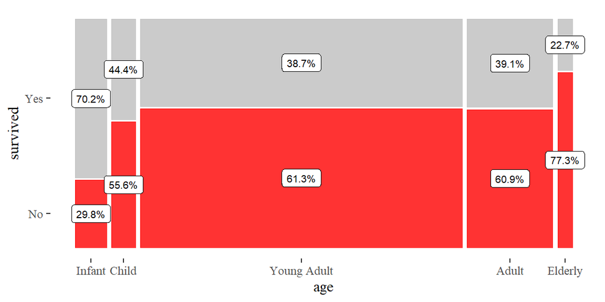

````markdown
```{r}
#| fig.width: 6
#| fig.height: 3
#| label: fig-mosaic2
#| fig-cap: "Mosaic plot of survived by age (Titanic dataset)."

p <- b_titanic %>%
  filter(!is.na(survived) & !is.na(age)) %>%
  mutate(age = cut(age,
                   breaks = c(0,6,15,40,60,100),
                   labels = c("Infant","Child","Young Adult",
                              "Adult","Elderly"))) %>%
  ggplot() +
  geom_mosaic(aes(x = product(survived, age),
                  filled = survived)) +
  scale_fill_manual("legend",
                    values = c("No" = "red",
                               "Yes" = "grey")) +
  theme_tufte()
add_percent_label(p)
```
````

````markdown
```{r}
#| eval: false
#| label: tbl-xtab3
#| tbl-cap: "Cross table counts of sex by age grouping."

x <- b_titanic %>%
  filter(!is.na(survived) & !is.na(age)) %>%
  mutate(age = cut(age,
                   breaks = c(0,6,15,40,60,100),
                   labels = c("Infant","Child","Young Adult",
                              "Adult","Elderly")),
         survived = ifelse(survived == 1, "Yes", "No"))
table(x$survived, x$age)
```
````

When splitting by sex, we see that there is very little difference in survival rates for the first two age groups (0 to 15) (Figure 9). But, above the age of 15, survival rates start to diverge for females and males. Females have a higher rate of survival than males. We also see that the age group of 6 to 15 expands to be from age 6 to around age 20 with survival rates slowly lifting from around age 20 to 25.

Figure 9: Cummulative plot of survived by age split by sex (Titanic dataset).

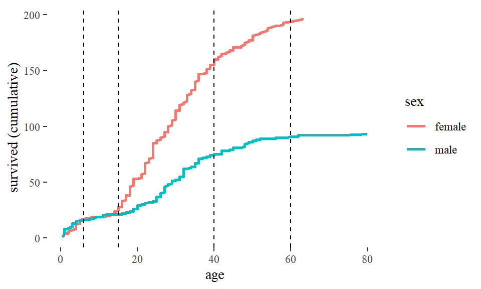

````markdown
```{r fig.width=5, fig.height=3}
#| fig.width: 5
#| fig.height: 3
#| label: fig-line2
#| fig-cap: "Cummulative plot of survived by age split by sex (Titanic dataset)."

x <- b_titanic %>%
  filter(!is.na(survived) & !is.na(age)) %>%
  group_by(sex) %>%
  arrange(sex, age) %>%
  mutate(survived = ifelse(survived == "Yes", 1, 0)) %>%
  mutate(survived = cumsum(survived))
ggplot(x,
       aes(x = age,
           y = survived,
           colour = sex)) +
  geom_line(linewidth = 1) +
  geom_vline(xintercept = c(6,15,40,60),
             linetype = "dashed",
             colour = "black") +
  ylab("survived (cumulative)") +
  theme_tufte()
```
````

If you were female and were a child aged between 6 to 15 your chances of survival were lower than if you were female of any other age (Figure 10). If you were male, your chances of survival were slightly better if you were a child (ages 6 to 15) or an infant (ages <6).

Figure 10: Mosaic plot of survived by survived and sex (Titanic dataset).

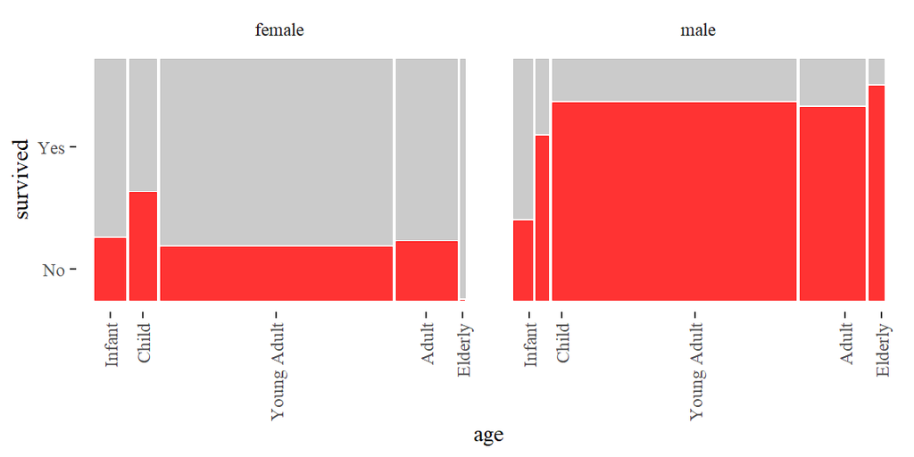

````markdown
```{r}
#| fig.width: 6
#| fig.height: 3
#| label: fig-mosaic3
#| fig-cap: "Mosaic plot of survived by survived and sex (Titanic dataset)."

x <- b_titanic %>%
  filter(!is.na(survived) & !is.na(age)) %>%
  mutate(age = cut(age,
                   breaks = c(0,6,15,40,60,100),
                   labels = c("Infant","Child","Young Adult","Adult","Elderly")))
ggplot(data=x) +
  geom_mosaic(aes(x = product(survived, age),
                  filled = survived)) +
  facet_grid(~sex) +
  scale_fill_manual("legend",
                    values = c("No" = "red",
                               "Yes" = "grey")) +
  theme_tufte() +
  theme(axis.text.x = element_text(angle=90, vjust=0.5, hjust=1))
```
````

Passengers with a sibsp of 1 have roughly a 50-50 chance of survival (Figure 11). Passengers with a sibsp of 3 or 4 have a very low chance of survival (<25%) while passengers with a sibsp greater than 4 had no chance. For those passengers with no sibsp, the chances of survival were 1 in 3 (35%).

Figure 11: Mosaic plot of survived by sibsp (Titanic dataset).

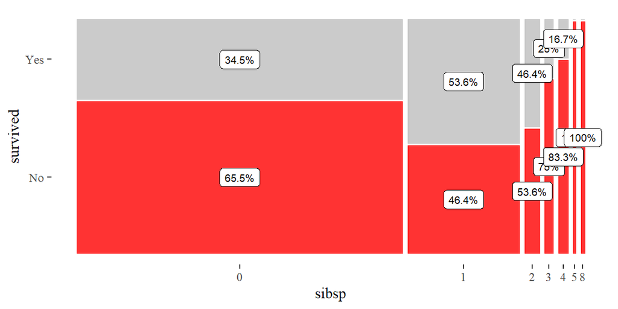

````markdown
```{r}
#| fig.width: 6
#| fig.height: 3
#| label: fig-mosaic4
#| fig-cap: "Mosaic plot of survived by sibsp (Titanic dataset)."

p <- b_titanic %>%
  filter(!is.na(survived) & !is.na(sibsp)) %>%
  ggplot() +
  geom_mosaic(aes(x = product(survived,sibsp),
                  filled = survived)) +
  scale_fill_manual("legend",
                    values = c("No" = "red",
                               "Yes" = "grey")) +
  theme_tufte()
add_percent_label(p)
```
````

````markdown
```{r}
#| eval: false
#| label: tbl-xtab4
#| tbl-cap: "Cross table counts of survived by sibsp."
table(b_titanic$survived, b_titanic$sibsp)
```
````

First class passengers are more likely to have survived with a 2 in 3 chance of survival (63%), than 2nd and 3rd class passengers (Figure 12). Survival chances drop to roughly a 50-50 chance for 2nd class passengers while 3rd class passengers are the unlucky lot with only a 1 in 4 chance of survival (24%).

Figure 12: Mosaic plot of survived by pclass (Titanic dataset).

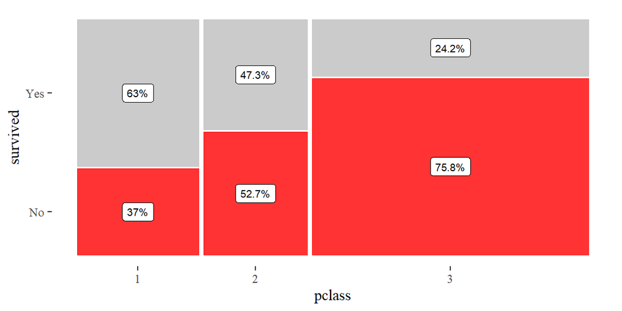

````markdown
```{r}
#| fig.width: 6
#| fig.height: 3
#| label: fig-mosaic5
#| fig-cap: "Mosaic plot of survived by pclass (Titanic dataset)."

p <- b_titanic %>%
  filter(!is.na(survived) & !is.na(pclass)) %>%
  ggplot() +
  geom_mosaic(aes(x = product(survived,pclass),
                  filled = survived)) +
  scale_fill_manual("legend",
                    values = c("No" = "red",
                               "Yes" = "grey")) +
  theme_tufte()
add_percent_label(p)
```
````

````markdown
```{r}
#| eval: false
#| label: tbl-xtab5
#| tbl-cap: "Cross table counts of survived by pclass."
table(b_titanic$survived, b_titanic$pclass)
```
````

Figure 13: Mosaic plot of survived by deck (Titanic dataset).

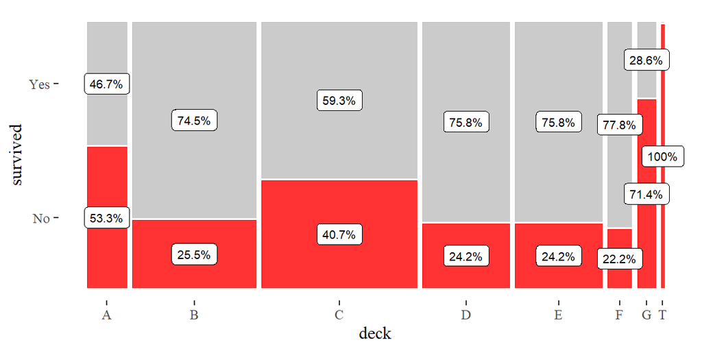

````markdown
```{r}
#| fig.width: 6
#| fig.height: 3
#| label: fig-mosaic6
#| fig-cap: "Mosaic plot of survived by deck (Titanic dataset)."

p <- b_titanic %>%
  filter(!is.na(survived) & !is.na(deck)) %>%
  ggplot() +
  geom_mosaic(aes(x = product(survived,deck),
                  filled = survived)) +
  scale_fill_manual("legend",
                    values = c("No" = "red",
                               "Yes" = "grey")) +
  theme_tufte()
add_percent_label(p)
```
````

Figure 14: Mosaic plot of survived by deck for males (Titanic dataset).

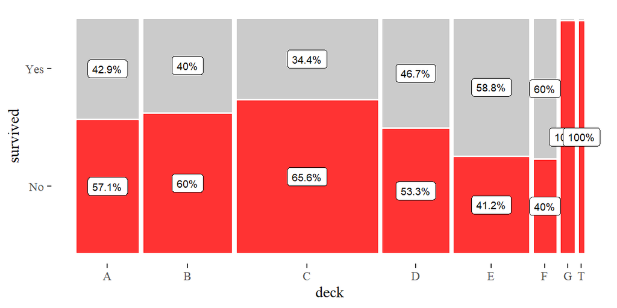

````markdown
```{r}
#| fig.width: 6
#| fig.height: 3
#| label: fig-mosaic7
#| fig-cap: "Mosaic plot of survived by deck for males (Titanic dataset)."

p <- b_titanic %>%
  filter(!is.na(survived) & !is.na(deck) & sex=="male") %>%
  ggplot() +
  geom_mosaic(aes(x = product(survived,deck),
                  filled = survived)) +
  scale_fill_manual("legend",
                    values = c("No" = "red",
                               "Yes" = "grey")) +
  theme_tufte()
add_percent_label(p)
```
````

The indirect association of embarked with survived is through the direct association with sex, sibsp, and pclass which are directly related to survived.

Nearly 2/3 rds of the passengers that departed from Southampton (S) and Queenstown (Q) did not survive.

Passengers that embarked from Southampton (“S”) have the least chances of survival while those that embarked from Cherbourg (“C”) have the highest chances of survival (Figure 15). Why?

Figure 15: Mosaic plot of survived by embarked (Titanic dataset).

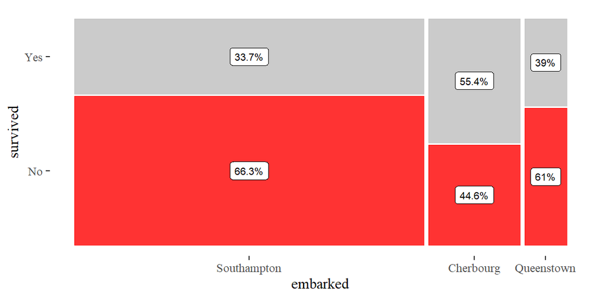

````markdown
```{r}
#| fig.width: 6
#| fig.height: 3
#| label: fig-mosaic8
#| fig-cap: "Mosaic plot of survived by embarked (Titanic dataset)."

p <- b_titanic %>%
  filter(!is.na(embarked) & !is.na(survived)) %>%
  ggplot() +
  geom_mosaic(aes(x = product(survived,embarked),
                  filled = survived)) +
  scale_fill_manual("legend",
                    values=c("No" = "red",
                             "Yes" = "grey")) +
  theme_tufte()
add_percent_label(p)
```
````

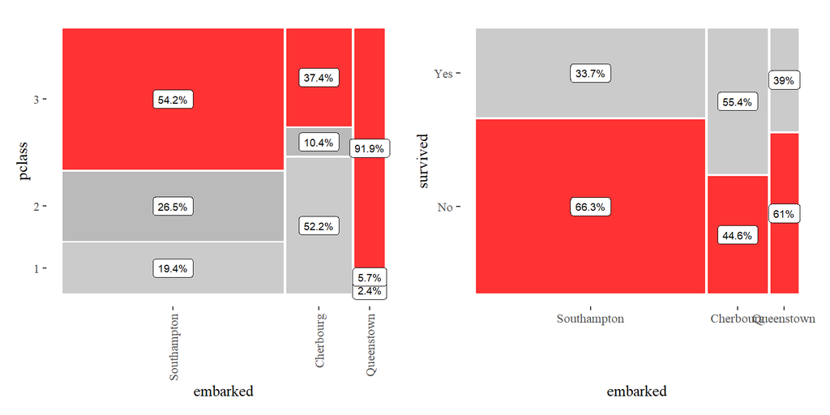

````markdown
```{r}
#| fig.width: 8
#| fig.height: 4
#| label: fig-mosaic9
#| fig-cap: "Mosaic plot of pclass and sex by embarked (Titanic dataset)."

p1 <- b_titanic %>%
  filter(!is.na(embarked) & !is.na(pclass)) %>%
  ggplot() +
  geom_mosaic(aes(x = product(pclass,embarked),
                  filled = pclass)) +
  scale_fill_manual("legend",
                    values = c("3" = "red",
                               "2" = "darkgrey",
                               "1" = "grey")) +
  theme_tufte() +
  theme(axis.text.x = element_text(angle=90, vjust=0.5, hjust=1))
p1 <- add_percent_label(p1)

p2 <- b_titanic %>%
  filter(!is.na(embarked) & !is.na(sex)) %>%
  ggplot() +
  geom_mosaic(aes(x = product(sex,embarked),
                  filled = sex)) +
  scale_fill_manual("legend",
                    values = c("male" = "red",
                               "female" = "grey")) +
  scale_x_discrete(position = "top") +
  theme_tufte() +
  theme(axis.text.x = element_text(angle=90, vjust=0.5, hjust=1))
p2 <- add_percent_label(p)

p1 + p2 + plot_layout(ncol=2)
```
````

## Adjust initial Bayesian Network using edge constraints (white and black lists)

Links between variables in Bayesian Networks can be constrained using whitelists and blacklists. Whitelists define the links that must occur in the trained network. Blacklists define links that cannot be included in the trained network. A whitelist is used to ensure that the link between title and age exists in the trained Bayesian Network. A blacklist is used to enforce edges connecting with survived are directed toward survived.

````markdown
```{targets titanic_bn2}
#| label: titanic_bn2
#| tar_simple: true
#| tar_interactive: false
#| output: false

tar_target(titanic_bn2, {
  flds <- c("survived","title","sex","age","sibsp","parch",
            "embarked","deck","fare","pclass")
  x <- b_titanic[, flds]
  wl <- data.frame(from = "title",
                   to = "age")
  bl <- bnlearn::tiers2blacklist(list(flds[-1], "survived"))
  bn <- structural.em(x,
                      maximize.args = list(whitelist=wl, blacklist=bl),
                      return.all = TRUE,
                      impute = "parents")
  bn
})
```
````

Build the Bayesian Network `titanic_bn2` with link constraints (whitelist and blacklist) and load into memory.

````markdown
```{r}
#| output: false
#| message: false
#| error: false
if (length(tar_outdated()) > 0) {
  tar_make()
}
tar_load(titanic_bn2)
```
````

Figure 17: Bayesian Network (BN2).

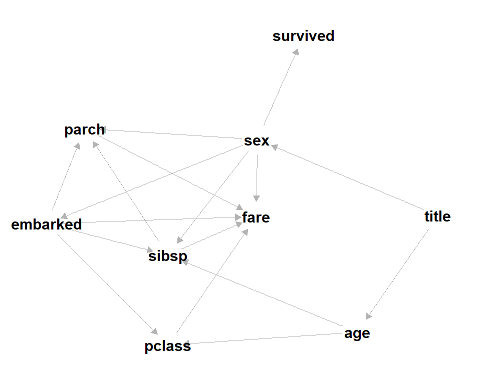

````markdown
```{r}
#| fig.width: 5
#| fig.height: 4
#| label: fig-bn2
#| fig-cap: "Bayesian Network (BN2)."
plot_bn(titanic_bn2$fitted)
```
````

## Process the tickets variable

The ticket variable contains information that groups observations (families) and defines the common values for embarked, cabin or cabins, and fare for those groups. Additionally, the ticket variable could also be used to help determine the composition of the group or family (such as mother and young child, brothers, sisters, alone).

Note that some cabins are listed with a prefix of “F”, for example “F G63” (ticket 348121). What does the prefix “F” mean?

````markdown
```{r}
#| eval: false
df <- tar_read(b_titanic) %>%
  group_by(ticket) %>%
  summarize(group_size = n(),
            cabin = paste(unique(cabin), collapse=" ")) %>%
  filter(str_length(cabin) > 4)
```
````

````markdown
```{targets a_tickets}
#| label: a_tickets
#| tar_simple: true
#| tar_interactive: false
#| output: false

tar_target(a_tickets, {
  df <- a_titanic

  df$fare <- ifelse(is.na(df$fare), 0, df$fare)
  df$cabin <- ifelse(is.na(df$cabin), "", df$cabin)
  df$embarked <- ifelse(is.na(df$embarked), "", as.character(df$embarked))

  df$n_adult <- ifelse(df$age>=16, 1, 0)
  df$n_child <- ifelse(df$age>3 & df$age<16, 1, 0)
  df$n_infant <- ifelse(df$age<3, 1, 0)

  df <- df %>%
    group_by(ticket) %>%
    summarize(group_size = n(),
              pclass = min(pclass, na.rm=TRUE),
              fare = max(fare),
              cabin = paste(unique(cabin), collapse=" "),
              embarked = paste(unique(embarked), collapse=" "),
              n_adult = sum(n_adult),
              n_child = sum(n_child),
              n_infant = sum(n_infant))

  df$group_size <- as.numeric(df$group_size)
  df$group_class <- cut(df$group_size,
                        breaks = c(0,1,4,6,11),
                        labels = c("Alone","Small","Medium","Large"))

  df$fare <- ifelse(df$fare == 0, NA, df$fare)

  df$embarked <- ifelse(df$embarked == "", NA, df$embarked)
  df$embarked <- ifelse(df$embarked == "S C", "C", df$embarked)
  df$embarked <- factor(df$embarked)

  df$cabin <- ifelse(df$cabin == "", NA, df$cabin)
  df$cabin <- sub("^ ", "", df$cabin)
  df$n_cabins <- as.numeric(sapply(strsplit(df$cabin, split=" "), length))

  df$unit_fare <- df$fare / df$n_cabins

  df$deck <- df$cabin
  df$deck <- gsub("[[:digit:]].*", "", df$deck)
  df$deck_f <- ifelse(is.na(df$deck), NA, grepl(" .", df$deck))
  df$deck <- gsub(". ", "", df$deck)

  df <- as.data.frame(df)
  df
})
```
````

Build the `a_tickets` data frame and load into memory.

````markdown
```{r}
#| output: false
#| message: false
#| error: false
if (length(tar_outdated()) > 0) {
  tar_make()
}
tar_load(a_tickets)
```
````

The tickets data `a_tickets` is further processed to select only those observations that have a value for deck, embarked, and fare (unit fare). This data is used for filling in missing values for deck and fare.

````markdown
```{targets a_ticket_price}
#| label: a_ticket_price
#| tar_simple: true
#| tar_interactive: false
#| output: false

tar_target(a_ticket_price, {
  #df <- a_tickets[order(a_tickets$deck,
  #                      a_tickets$embarked),
  #                c("embarked", "deck", "n_cabins", "fare")]
  #df <- df %>%
  #  group_by(embarked, deck, n_cabins) %>%
  #  summarise(fare = median(fare, na.rm=TRUE))
  #df <- df[complete.cases(df), ]

  df <- a_tickets[order(a_tickets$deck,
                        a_tickets$embarked),
                  c("embarked", "deck", "unit_fare")]
  df <- df[complete.cases(df), ]
  df <- df[!duplicated(df), ]
  df
})
```
````

Build the `a_ticket_price` data frame and load into memory.

````markdown
```{r}
#| output: false
#| message: false
#| error: false
if (length(tar_outdated()) > 0) {
  tar_make()
}
tar_load(a_ticket_price)
```
````

The price of a ticket (fare) is strongly dependent on the number of cabins, deck, and to a less extent embarked (Figure 18). Interestingly the fare for cabins on Deck A is less than the fare for cabins on Decks B and C and is similar to Decks D and E. Cabins on Deck G have the lowest fare. The ticket price is lowest when embarking from Queenstown, and high when embarking from Cherbourg. Why is embarking from Southampton cheaper than embarking Cherbourg when the journey from Cherbourg is shorter than Southampton?

Figure 18: Boxplots of fare by embarked, deck, and number of cabins.

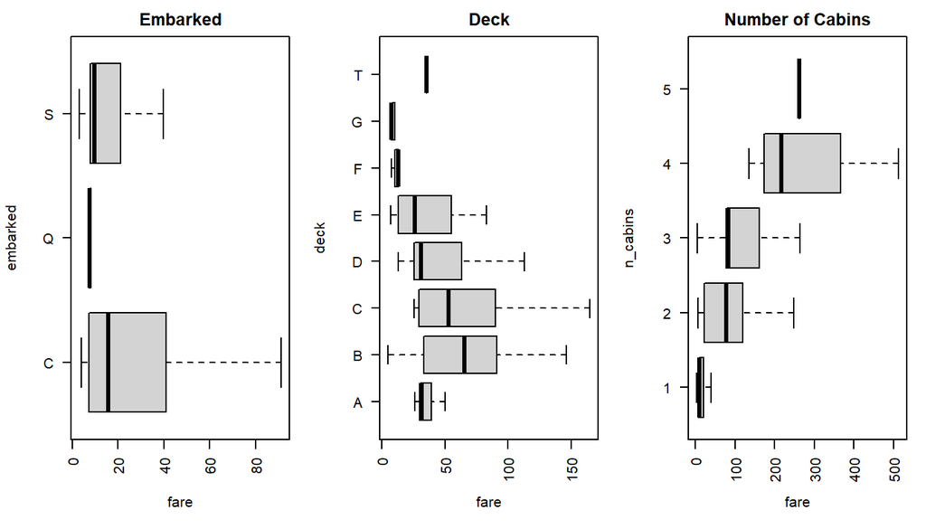

````markdown
```{r fig.width=6, fig.height=3}
#| fig.width: 7
#| fig.height: 4
#| label: fig-box3
#| fig-cap: "Boxplots of fare by embarked, deck, and number of cabins."

par(mfrow=c(1,3), mar=c(5.1,4.1,2.1,1.1))

boxplot(fare ~ embarked,
        data = a_tickets,
        horizontal = TRUE,
        pch = 16,
        las = 2,
        main = "Embarked",
        outline = FALSE)

boxplot(fare ~ deck,
        data = a_tickets,
        horizontal = TRUE,
        pch = 16,
        las = 2,
        main = "Deck",
        outline = FALSE)

boxplot(fare ~ n_cabins,
        data = a_tickets,
        horizontal = TRUE,
        pch = 16,
        las = 2,
        main = "Number of Cabins",
        outline = FALSE)
```
````

The price of a ticket (fare) is strongly dependent on the number of adults, children, and infants (Figure 19). As the number of passengers on a ticket increases, the fare increases. Is this relationship linear? Note that the fare for seven passengers is lower than the median fare for three or more passengers. Is this an error in the data or a discount for such a large group or is the group squeezed into a small number of cabins?

Figure 19: Boxplots of fare by number of adults, children, and infants.

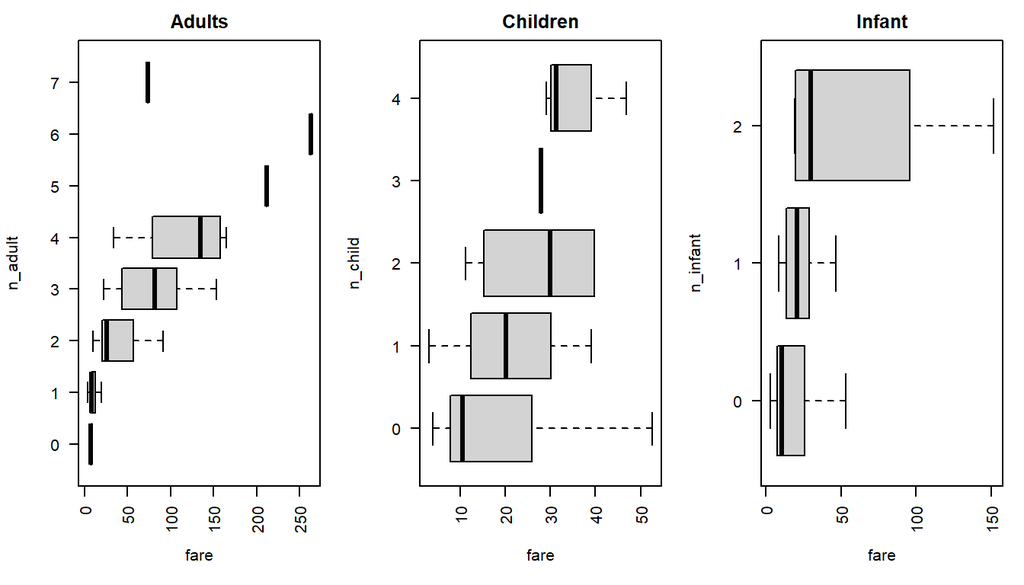

````markdown
```{r fig.width=6, fig.height=3}
#| fig.width: 7
#| fig.height: 4
#| label: fig-box4
#| fig-cap: "Boxplots of fare by number of adults, children, and infants."

par(mfrow=c(1,3), mar=c(5.1,4.1,2.1,1.1))

boxplot(fare ~ n_adult,
        data = a_tickets,
        horizontal = TRUE,
        pch = 16,
        las = 2,
        main = "Adults",
        outline = FALSE)

boxplot(fare ~ n_child,
        data = a_tickets,
        horizontal = TRUE,
        pch = 16,
        las = 2,
        main = "Children",
        outline = FALSE)

boxplot(fare ~ n_infant,
        data = a_tickets,
        horizontal = TRUE,
        pch = 16,
        las = 2,
        main = "Infant",
        outline = FALSE)
```
````

To impute missing values for deck, a simple nearest neighbour estimator was used using the ticket fare. Would it be possible to infer a pricing model from the data? This will be left for a separate data science project.

````markdown
```{targets b_tickets}
#| label: b_tickets
#| tar_simple: true
#| tar_interactive: false
#| output: false

tar_target(b_tickets, {
  df <- a_tickets
  i <- is.na(df$deck) & !is.na(df$unit_fare)
  idx <- RANN::nn2(a_ticket_price$unit_fare,
                   df$unit_fare[i],
                   k = 1)
  df$deck <- ifelse(i, a_ticket_price$deck[idx$nn.idx], df$deck)
  df$deck <- factor(df$deck,
                    levels = c("A","B","C","D","E","F","G"))
  df
})
```
````

Build the `b_tickets` data frame with missing values for deck imputed using nearest neighbour, and load into memory.

````markdown
```{r}
#| output: false
#| message: false
#| error: false
if (length(tar_outdated()) > 0) {
  tar_make()
}
tar_load(b_tickets)
```
````

A Bayesian Network can be trained on the tickets data which could be used for imputing missing values and gaining further insights into the pricing model.

````markdown
```{targets tickets_bn1}
#| label: tickets_bn1
#| tar_simple: true
#| tar_interactive: false
#| output: false

tar_target(tickets_bn1, {
  flds <- c("fare","pclass","embarked","group_size","group_class",
            "n_adult","n_child","n_infant","n_cabins","unit_fare","deck")
  x <- b_tickets[, flds]
  wl <- data.frame(from = c("deck","embarked"),
                   to = rep("fare",2))
  bn <- structural.em(x,
                      maximize.args = list(whitelist=wl, blacklist=NULL),
                      return.all = TRUE,
                      impute = "parents")
  bn
})
```
````

Build the Bayesian Network trained on the `b_tickets` data frame and load into memory.

````markdown
```{r}
#| output: false
#| message: false
#| error: false
if (length(tar_outdated()) > 0) {
  tar_make()
}
tar_load(tickets_bn1)
```
````

The Bayesian Network trained on the tickets data (Figure 20) indicates that fare is directly associated with deck, embarked, number of adults, and passenger class. Why is the number of infants, group_class, group_size, and number of cabins connected with passenger class. Passenger class is related to the cabin (deck) and consequently ticket fare, not group size or number of cabins. Although, it is more likely that first class passengers with a large group size will occupy more cabins than third class passengers.

Figure 20: Bayesian Network (BN3).

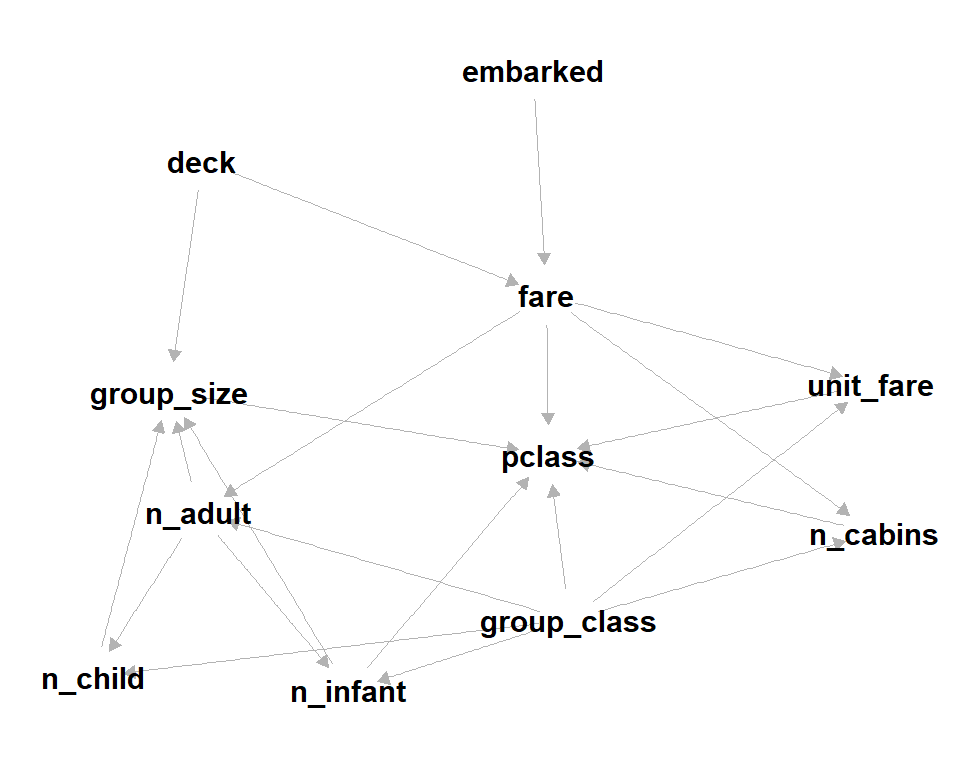

````markdown
```{r}
#| fig.width: 5
#| fig.height: 4
#| label: fig-bn3
#| fig-cap: "Bayesian Network (BN3)."
plot_bn(tickets_bn1$fitted)
```
````

## Add processed tickets data to the Titanic data

The processed tickets data (`b_tickets`) was merged with the processed Titanic data (`b_titanic`) by ticket to generate the `c_titanic` data frame. The variable deck in `b_titanic` was replaced by the values in `b_tickets`. The variables group_size, group_class, n_cabins, unit_fare, deck, n_infant, n_child, and n_adult from the `b_tickets` data were added to the `b_titanic` data.

````markdown
```{targets c_titanic}
#| label: c_titanic
#| tar_simple: true
#| tar_interactive: false
#| output: false

tar_target(c_titanic, {
  df1 <- b_titanic[, setdiff(names(b_titanic), "deck")]

  df2 <- b_tickets
  i <- is.na(df2$deck) & !is.na(df2$unit_fare)
  df2$deck[i] <- tickets_bn1$imputed$deck[i]
  flds <- c("ticket","group_size","group_class","n_cabins",
            "unit_fare","deck","n_infant","n_child","n_adult")
  df2 <- df2[, flds]

  df <- merge(df1, df2, by="ticket")
  i <- !is.na(df$group_class) & df$group_class == "Alone"
  df$n_infant[i] <- 0
  df$n_child[i] <- 0
  df$n_adult[i] <- 1

  df
})
```
````

Build the `c_titanic` data frame and load into memory.

````markdown
```{r}
#| output: false
#| message: false
#| error: false
if (length(tar_outdated()) > 0) {
  tar_make()
}
tar_load(c_titanic)
```
````

## Retrain Bayesian Network with the additional variables from tickets

A Bayesian Network was trained on the `c_titanic` data with the inclusion of the additional variables derived from processing the tickets variable. A whitelist was used to constrain the network to include the links title -> age, deck -> fare, and embarked -> fare.

````markdown
```{targets titanic_bn3}
#| label: titanic_bn3
#| tar_simple: true
#| tar_interactive: false
#| output: false

tar_target(titanic_bn3, {
  flds <- c("survived","title","sex","age","sibsp","parch",
            "embarked","deck","pclass","fare","unit_fare",
            "group_size","group_class",
            "n_cabins","n_infant","n_child","n_adult")
  x <- c_titanic[, flds]
  wl <- data.frame(from = c("title","deck","embarked"),
                   to = c("age", rep("fare",2)))
  bl <- bnlearn::tiers2blacklist(list(flds[-1], "survived"))
  bn <- structural.em(x,
                      maximize.args = list(whitelist=wl, blacklist=bl),
                      return.all = TRUE,
                      impute = "bayes-lw")
  bn
})
```
````

Build the Bayesian Network `titanic_bn3` with the added variables from the tickets data frame and load into memory.

````markdown
```{r}
#| output: false
#| message: false
#| error: false
if (length(tar_outdated()) > 0) {
  tar_make()
}
tar_load(titanic_bn3)
```
````

The Bayesian Network trained on the processed Titanic data `c_titanic` is illustrated as a directed acyclic graph shown in Figure 21. Note that survived is now only directly associated with sex and group_class.

Figure 21: Bayesian Network (BN4).

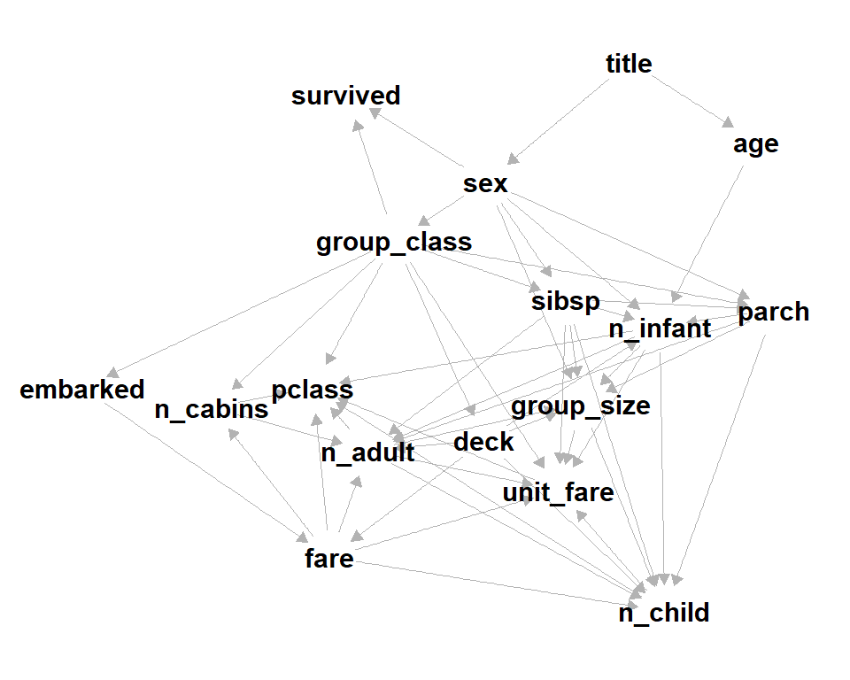

````markdown
```{r}
#| fig.width: 5
#| fig.height: 4
#| label: fig-bn4
#| fig-cap: "Bayesian Network (BN4)."

plot_bn(titanic_bn3$fitted, "dh")
```
````

The mosaic plot of survived by group_class (Figure 22) is similar to the mosaic plot of survived by sibsp (Figure 11). A small group size has the highest chance of survival at almost 60%. All other group sizes have similar chances of survival at around 25%. The high probability of survival for a small group size is likely due to the small groups made up of a mother and child (or infant) being more likely to survive.

Figure 22: Mosaic plot of survived by group_class (processed Titanic dataset).

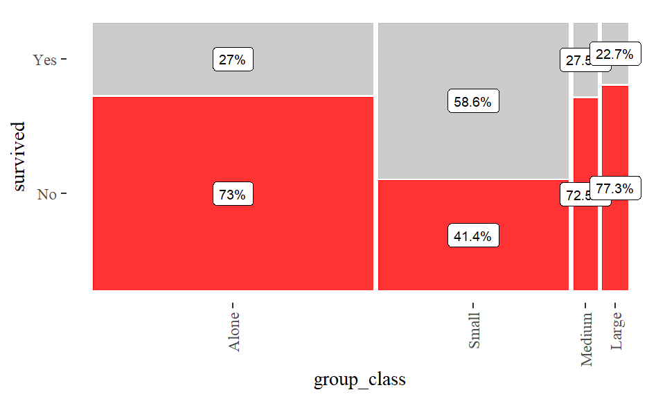

````markdown
```{r}
#| fig.width: 5
#| fig.height: 3
#| label: fig-mosaic10
#| fig-cap: "Mosaic plot of survived by group_class (processed Titanic dataset)."

p <- c_titanic %>%
  filter(!is.na(survived) & !is.na(group_class)) %>%
  ggplot() +
  geom_mosaic(aes(x = product(survived, group_class),
                  filled = survived)) +
  scale_fill_manual("legend",
                    values=c("No" = "red",
                             "Yes" = "grey")) +
  theme_tufte() +
  theme(axis.text.x = element_text(angle=90, vjust=0.5, hjust=1))
add_percent_label(p)
```
````

# Stories of survival

The trained Bayesian Network can be used to explore relationships between variables in the Titanic data set and gain insight into surviving the catastrophe. One novel way of doing this is through fictitious or hypothetical stories.

You are a young mother aged 34 with two children, one girl aged 3 and one boy aged 8. You are travelling with your two children, your mother and your older brother. Your mother and brother are in adjacent cabins. After a long day looking after your children and socializing you are woken from a heavy sleep by your kids and a knock on the door. You open the door and it is your mother and brother standing in the corridor with other passengers. Your mother looks concerned, your brother is calm. You are told to get the kids and muster. Something has happened. As a group of five you all pile into the corridors along with other passengers and head to the muster point. An hour or so has passed waiting at the muster point, people are calling all mothers with young children to get on one of the lifeboats. Your only allowed to take your daughter on the lifeboat. What do you do? Your choice determines whether you survive or not. Most mothers chose to get on the lifeboat with their child.

````markdown
```{r}
#| eval: false
#set.seed(1)
bnlearn::cpquery(titanic_bn3$fitted,
        event = (survived == "Yes"),
        evidence = (sex == "female"
                    & age >= 30
                    & age < 40
                    & parch == "3"
                    & sibsp == "1"))
```
````

You are an elderly male aged 64 years. You are travelling alone. You boarded the Titanic at Southampton looking to catch-up with family that are already in the United States of America (USA). After dining at the captains table you settle into your cabin on deck B and fall asleep. At just before midnight you are suddenly awoken. What the … About five minutes later the captain tells everyone to muster. Unfortunately you don’t get on a lifeboat, you don’t get to see your family in the USA. You don’t survive.

````markdown
```{r}
#| eval: false
#set.seed(1)
bnlearn::cpquery(titanic_bn3$fitted,
        event = (survived == "Yes"),
        evidence = (sex == "male"
                    & age > 60
                    & embarked == "Southampton"
                    & group_class == "Alone"))
```
````

You are a young adult male aged 21 years. You are travelling alone. You boarded the Titanic at Queenstown looking to emigrate to the United States of America (USA) to start a new life. You have little money and spent little on the fare. Unfortunately you never make it to the USA. Somehow you manage to survive, barely. The odds are against you, a 1 in 10 chance.

````markdown
```{r}
#| eval: false
#set.seed(1)
bnlearn::cpquery(titanic_bn3$fitted,
        event = (survived == "Yes"),
        evidence = (sex == "male"
                    & age > 18
                    & age < 25
                    & embarked == "Queenstown"
                    & group_class == "Alone"
                    & fare < 5))
```
````

You are a young adult female aged 25 years. You just got married. You are travelling with your husband aged 27 years. You boarded the Titanic at Cherbourg in France for the trip of a life time. You have been looking forward to spending time with your husband exploring the USA for 2 months while on honeymoon. You have been partying with your husband, had some drinks in the bar till late at night. You are still in the bar listening to music and drinking beer. Your husband looks at you - What was that? The engines stopped. It is just before midnight. There is some commotion going on and talk of an iceberg hitting the ship. Nope, it’s all good, the crew has got this, the ship could not possibly hit an iceberg. You continue enjoying your drink. After sometime the crew tells you and your husband that you must muster. You ignore their directions. An hour or two passes and you hear people saying abandon ship, abandon ship. You and your husband dismiss it. That was your mistake. Unfortunately you did not get to enjoy your honeymoon. You did not survive. You could have survived if only you followed instructions, maybe. The modelling suggest that a young adult female travelling with one other has a moderate chance of survival. Your partner on the other hand, may not have survived. His chances of survival were lower than yours.

````markdown
```{r}
#| eval: false
#set.seed(1)
bnlearn::cpquery(titanic_bn3$fitted,
        event = (survived == "Yes"),
        evidence = (sex == "female"
                    & age > 22
                    & age < 29
                    & embarked == "Cherbourg"
                    & parch == "2"
                    & sibsp == "0"))
```
````

````markdown
```{r}
#| eval: false
#set.seed(1)
bnlearn::cpquery(titanic_bn3$fitted,
        event = (survived == "Yes"),
        evidence = (sex == "male"
                    & age > 22
                    & age < 29
                    & embarked == "Cherbourg"
                    & parch == "2"
                    & sibsp == "0"))
```
````

This last story highlights deficiencies in the preparation of the data. It is not easy to determine what the probability is of a couple or an entire group with a certain composition surviving using the data as it is. For example to determine if a group consisting of a mother and child would require selecting observations where (sex == “female” and n_adult == 1 and n_child+n_infant == 1) or (n_adult == 1 and n_child+n_infant == 1). But this would also select children where the parent was male. However, the tickets data could be used. For this, the preparation of the tickets data would require the inclusion of the number of survivors in the group and that there are no missing values for survived.

````markdown
```{r}
#| output: false
#| warning: false
#| message: false

flds <- names(titanic_bn3$fitted)
df <- impute(titanic_bn3$fitted,
             c_titanic[, flds],
             method = "parents")
df$ticket <- c_titanic$ticket
df$survived <- ifelse(df$survived == "Yes", 1, 0)
df$sex <- ifelse(df$sex == "male", 1, 0)
df <-  df %>%
  group_by(ticket) %>%
  summarize(n_survived = sum(survived),
            couple = n() == 2 & sum(sex) == 1,
            family = n() > 1 & (n_child+n_infant)>0,
            group_size = n()) %>%
  mutate(all_survived = n_survived == group_size)

couples_survived <- {
  x <- sum(df$couple == TRUE & df$all_survived == TRUE)
  y <- sum(df$couple == TRUE)
  x / y * 100
}
couples_survived <- round(couples_survived, 1)
```
````

Based on the predictions from the Bayesian Network, only 20.5% of the couples survived the catastrophe.

# Add latent variables to simplify Bayesian Network

A latent variable, is a variable that has no values, it is unobserved. A latent variable maybe inferred from the data or defined from expert knowledge of the causal effects. The latent variable can be discrete or continuous.

Bayesian Networks can model both discrete and continuous latent variables by including a variable in the training data that has no values and is of the desired type. Latent variables in Bayesian Networks can be used to model non-linear relationships and non-Gaussian distributions. A Gaussian Mixture model is a good latent variable model that can be used for this purpose.

For the Titanic data set, three latent variables are inferred from the relationships between the variables. Latent Variable 1 is connected to survived, parch, sibsp, and group_class and represents group composition (family). Latent Variable 2 is connected to survived, age, age_class, and sex and represents individual characteristics, albeit limited. Latent Variable 3 is connected to survived, deck, passenger class, and group_class and represents the proximity of the passengers cabin to the life boats (closer to the boats = closer to getting on the boats <- front of the queue). The directed acyclic graph of the proposed Bayesian Network with latent variables is shown in Figure 23.

Figure 23: Directed Acyclic Graph showing the connections of the three latent variables with Titanic data variables.

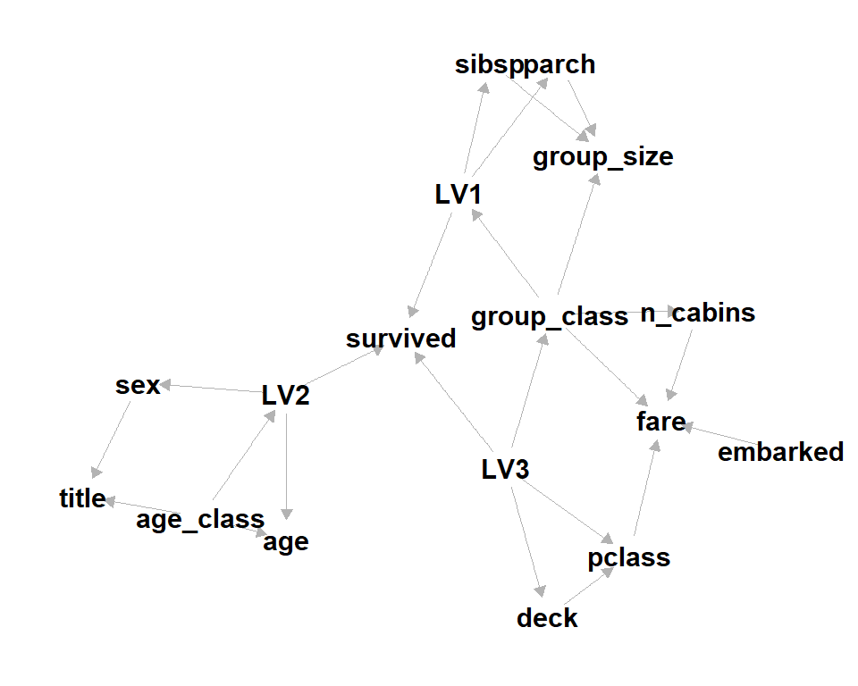

````markdown
```{r}
#| fig.width: 5
#| fig.height: 4
#| label: fig-dag
#| fig-cap: "Directed Acyclic Graph showing the connections of the three latent variables with Titanic data variables."
dag <- dagify(
  survived ~ LV1 + LV2 + LV3,
  parch ~ LV1,
  sibsp ~ LV1,
  group_size ~ sibsp + parch + group_class,
  LV1 ~ group_class,

  age ~ LV2 + age_class,
  sex ~ LV2,
  title ~ sex + age_class,
  LV2 ~ age_class,

  pclass ~ deck + LV3,
  deck ~ LV3,
  group_class ~ LV3,

  n_cabins ~ group_class,
  fare ~ embarked + n_cabins + group_class + pclass
)

dag %>%
  tidy_dagitty(layout="gem", seed=1) %>%
  ggplot(aes(x=x, y=y, xend=xend, yend=yend)) +
  geom_dag_edges(aes(start_cap=ggraph::circle(3,"mm"), end_cap=ggraph::circle(3,"mm")),
                          edge_colour="grey70", edge_width=0.2) +
  geom_dag_text(colour="black", size=4) +
  theme_dag() +
  theme(plot.margin = unit(c(0.1, 0.1, 0.1, 0.1), "cm"))
```
````

## Latent Variable 1 (LV1)

A Bayesian Network (`titanic_bn_lv1`) was trained using the variables survived, sibsp, parch, group_size, and group_class and a single discrete latent variable LV1. The latent variable 1 is assumed to have seven distinct levels or groups. A whitelist and blacklist was used to constrain the connections between variables to match the proposed links shown in Figure 23.

````markdown
```{targets titanic_bn_lv1}
#| label: titanic_bn_lv1
#| tar_simple: true
#| tar_interactive: false
#| output: false

tar_target(titanic_bn_lv1, {
  set.seed(1)

  x <- c_titanic[, c("survived","sibsp","parch","group_size","group_class")]
  n <- 7
  x$LV1 <- factor(sample(1:n,
                         nrow(x),
                         replace = TRUE))

  bn <- bn.fit(empty.graph(names(x)),
               x)

  cpt <- coef(bn$LV1)
  cpt[1:n] <- rep(1/n, n)
  bn$LV1 <- cpt
  x$LV1 <- factor(rep(NA, nrow(x)),
                  levels = levels(x$LV1))

  wl <- data.frame(from = "LV1",
                   to = c("survived","sibsp","parch"))
  wl <- rbind(wl,
              data.frame(from = "group_class",
                         to = c("group_size","LV1")))
  wl <- rbind(wl, data.frame(from="group_size", to=c("sibsp","parch")))

  bl <- data.frame(from = c("sibsp","parch","group_size","group_class"),
                   to = "survived")
  bl <- rbind(bl,
              data.frame(from = "survived",
                         to = c("sibsp","parch","group_size","group_class")))
  bl <- rbind(bl,
              set2blacklist(c("group_class","sibsp","parch")))

  bn <- structural.em(x,
                      start = bn,
                      return.all = TRUE,
                      maximize.args = list(whitelist=wl,blacklist=bl),
                      impute = "bayes-lw",
                      impute.args = list(n=500))

  bn
})
```
````

Build the Bayesian Network `titanic_bn_lv1` latent variable model 1 and load into memory.

````markdown
```{r}
#| output: false
#| message: false
#| error: false
if (length(tar_outdated()) > 0) {
  tar_make()
}
tar_load(titanic_bn_lv1)
```
````

Trained latent variable Bayesian Network `titanic_bn_lv1` is shown in Figure 24.

Figure 24: Latent Variable LV1 Bayesian Network.

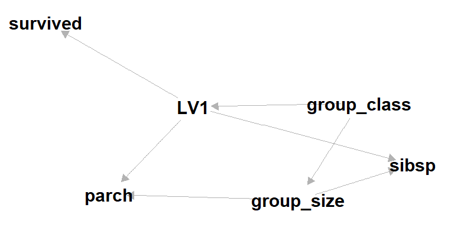

````markdown
```{r}
#| fig.width: 4
#| fig.height: 2
#| label: fig-bn-lv1
#| fig-cap: "Latent Variable LV1 Bayesian Network."
plot_bn(titanic_bn_lv1$fitted, "fr")
```
````

The cross table of survived by LV1 is shown in Table 1 (counts) and Table 2 (Bayesian Network probabilities).

````markdown
```{r}
#| label: tbl-lv1a
#| tbl-cap: "Cross table counts of survived by LV1."
df <- titanic_bn_lv1$imputed %>%
  filter(!is.na(c_titanic$survived)) %>%
  group_by(LV1, survived) %>%
  tally() %>%
  tidyr::spread(LV1, n)
knitr::kable(df)
```
````

Table 1: Cross table counts of survived by LV1.

| survived | 1 | 2 | 3 | 4 | 5 | 6 | 7 |
| --- | --- | --- | --- | --- | --- | --- | --- |
| No | 22 | 13 | 327 | 18 | 60 | 16 | 93 |
| Yes | 12 | 145 | 1 | 2 | 85 | NA | 97 |

````markdown
```{r}
#| label: tbl-lv1b
#| tbl-cap: "LV1 Bayesian Network probabilities for LV1 node."
df <- round(coef(titanic_bn_lv1$fitted$survived), 2) %>%
  as.data.frame() %>%
  tidyr::spread(LV1, Freq)
knitr::kable(df)
```
````

Table 2: LV1 Bayesian Network probabilities for LV1 node.

| survived | 1 | 2 | 3 | 4 | 5 | 6 | 7 |
| --- | --- | --- | --- | --- | --- | --- | --- |
| No | 0.49 | 0.07 | 1 | 0.92 | 0.6 | 1 | 0.65 |
| Yes | 0.51 | 0.93 | 0 | 0.08 | 0.4 | 0 | 0.35 |

## Latent Variable 2 (LV2)

A Bayesian Network (`titanic_bn_lv2`) was trained using the variables survived, age, sex, age_class and a single discrete latent variable LV2. The latent variable 2 is assumed to have three distinct levels or groups. A whitelist and blacklist was used to constrain the connections between variables to match the proposed links shown in Figure 23.

````markdown
```{targets titanic_bn_lv2}
#| label: titanic_bn_lv2
#| tar_simple: true
#| tar_interactive: false
#| output: false

tar_target(titanic_bn_lv2, {
  set.seed(1)

  x <- c_titanic[, c("survived","age","sex","age_class")]
  n <- 3
  x$LV2 <- factor(sample(1:n, nrow(x),
                         replace = TRUE))

  bn <- bn.fit(empty.graph(names(x)),
               x)

  cpt <- coef(bn$LV2)
  cpt[1:n] <- rep(1/n, n)
  bn$LV2 <- cpt
  x$LV2 <- factor(rep(NA, nrow(x)),
                  levels = levels(x$LV2))

  wl <- data.frame(from = "LV2",
                   to = c("survived","age","sex"))
  wl <- rbind(wl,
              data.frame(from = "age_class",
                         to = c("age","LV2")))

  bl <- data.frame(from = c("age","sex","age_class"),
                   to = "survived")
  bl <- rbind(bl,
              data.frame(from = "survived",
                         to = c("age","sex","age_class")))
  bl <- rbind(bl,
              set2blacklist(c("age_class","sex")))

  bn <- structural.em(x,
                      start = bn,
                      return.all = TRUE,
                      maximize.args = list(whitelist=wl,blacklist=bl),
                      impute = "bayes-lw",
                      impute.args = list(n=500))

  bn
})
```
````

Build the Bayesian Network `titanic_bn_lv2` latent variable model 2 and load into memory.

````markdown
```{r}
#| output: false
#| message: false
#| error: false
if (length(tar_outdated()) > 0) {
  tar_make()
}
tar_load(titanic_bn_lv2)
```
````

Trained latent variable Bayesian Network `titanic_bn_lv2` is shown in Figure 25.

Figure 25: Latent Variable LV2 Bayesian Network.

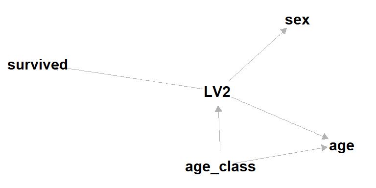

````markdown
```{r}
#| fig.width: 4
#| fig.height: 2
#| label: fig-bn-lv2
#| fig-cap: "Latent Variable LV2 Bayesian Network."
plot_bn(titanic_bn_lv2$fitted, "fr")
```
````

The cross table of survived by LV2 is shown in Table 3 (counts) and Table 4 (Bayesian Network probabilities).

````markdown
```{r}
#| label: tbl-lv2a
#| tbl-cap: "Cross table counts of survived by LV2."
df <- titanic_bn_lv2$imputed %>%
  filter(!is.na(c_titanic$survived)) %>%
  group_by(LV2, survived) %>%
  tally() %>%
  tidyr::spread(LV2, n)
knitr::kable(df)
```
````

Table 3: Cross table counts of survived by LV2.

| survived | 1 | 2 | 3 |
| --- | --- | --- | --- |
| No | 258 | 136 | 155 |
| Yes | 305 | 34 | 3 |

````markdown
```{r}
#| label: tbl-lv2b
#| tbl-cap: "LV2 Bayesian Network probabilities for LV2 node."
df <- round(coef(titanic_bn_lv2$fitted$survived), 2) %>%
  as.data.frame() %>%
  tidyr::spread(LV2, Freq)
knitr::kable(df)
```
````

Table 4: LV2 Bayesian Network probabilities for LV2 node.

| survived | 1 | 2 | 3 |
| --- | --- | --- | --- |
| No | 0.65 | 0.84 | 0.99 |
| Yes | 0.35 | 0.16 | 0.01 |

## Latent Variable 3 (LV3)

A Bayesian Network (`titanic_bn_lv3`) was trained using the variables survived, pclass, deck, group_class and a single discrete latent variable LV3. The latent variable 3 is assumed to have five distinct levels or groups. A whitelist and blacklist was used to constrain the connections between variables to match the proposed links shown in Figure 23.

````markdown
```{targets titanic_bn_lv3}
#| label: titanic_bn_lv3
#| tar_simple: true
#| tar_interactive: false
#| output: false

tar_target(titanic_bn_lv3, {
  set.seed(1)

  x <- c_titanic[, c("survived","pclass","deck","group_class")]
  n <- 5
  x$LV3 <- factor(sample(1:n,
                         nrow(x),
                         replace = TRUE))

  bn <- bn.fit(empty.graph(names(x)),
               x)

  cpt <- coef(bn$LV3)
  cpt[1:n] <- rep(1/n, n)
  bn$LV3 <- cpt
  x$LV3 <- factor(rep(NA,
                      nrow(x)),
                  levels = levels(x$LV3))

  wl <- data.frame(from = "LV3",
                   to = c("survived","pclass","deck","group_class"))
  wl <- rbind(wl,
              data.frame(from = "deck",
                         to = "pclass"))

  bl <- data.frame(from = c("pclass","deck","group_class"),
                   to = "survived")
  bl <- rbind(bl,
              data.frame(from = "survived",
                         to = c("pclass","deck","group_class")))
  bl <- rbind(bl,
              data.frame(from = "group_class",
                         to = c("pclass","deck")))

  bn <- structural.em(x,
                      start = bn,
                      return.all = TRUE,
                      maximize.args = list(whitelist=wl,blacklist=bl),
                      impute = "bayes-lw",
                      impute.args = list(n=500),
                      max.iter = 5)

  bn
})
```
````

Build the Bayesian Network `titanic_bn_lv3` latent variable model 3 and load into memory.

````markdown
```{r}
#| output: false
#| message: false
#| error: false
if (length(tar_outdated()) > 0) {
  tar_make()
}
tar_load(titanic_bn_lv3)
```
````

Trained latent variable Bayesian Network `titanic_bn_lv3` is shown in Figure 26.

Figure 26: Latent Variable LV3 Bayesian Network.

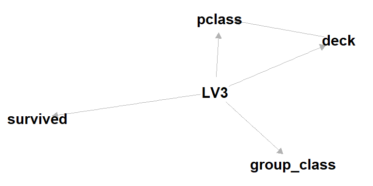

````markdown
```{r}
#| fig.width: 4
#| fig.height: 2
#| label: fig-bn-lv3
#| fig-cap: "Latent Variable LV3 Bayesian Network."
plot_bn(titanic_bn_lv3$fitted, "fr")
```
````

The cross table of survived by LV3 is shown in Table 5 (counts) and Table 6 (Bayesian Network probabilities).

````markdown
```{r}
#| label: tbl-lv3a
#| tbl-cap: "Cross table counts of survived by LV3."
df <- titanic_bn_lv3$imputed %>%
  filter(!is.na(c_titanic$survived)) %>%
  group_by(LV3, survived) %>%
  tally() %>%
  tidyr::spread(LV3, n)
knitr::kable(df)
```
````

Table 5: Cross table counts of survived by LV3.

| survived | 1 | 2 | 3 | 4 | 5 |
| --- | --- | --- | --- | --- | --- |
| No | 43 | 132 | 213 | 82 | 79 |
| Yes | 12 | 63 | 83 | 61 | 123 |

````markdown
```{r}
#| label: tbl-lv3b
#| tbl-cap: "LV3 Bayesian Network probabilities for LV3 node."
df <- round(coef(titanic_bn_lv3$fitted$survived), 2) %>%
  as.data.frame() %>%
  tidyr::spread(LV3, Freq)
knitr::kable(df)
```
````

Table 6: LV3 Bayesian Network probabilities for LV3 node.

| survived | 1 | 2 | 3 | 4 | 5 |
| --- | --- | --- | --- | --- | --- |
| No | 0.86 | 0.78 | 0.8 | 0.71 | 0.27 |
| Yes | 0.14 | 0.22 | 0.2 | 0.29 | 0.73 |

# Final Bayesian Network

The final Bayesian Network for this project is trained on the `c_titanic` data with latent variables added. The model is based on the directed acyclic graph defined in Figure 23.

The term “final” in this context is used to identify the last Bayesian Network for this Titanic data analysis project trained on the processed data. Final is not meant to suggest that it is the best and final model that could be trained and that there are no more improvements that could be made. Unfortunately, the term “final” does invoke the perception that there is no continuous improvement or continuous development. Data analytics projects are continuous improvement projects with no “final” model. This “final” model could be further improved.

````markdown
```{targets titanic_bn_final}
#| label: titanic_bn_final
#| tar_simple: true
#| tar_interactive: false
#| output: false

tar_target(titanic_bn_final, {
  dag <- "[survived][parch|LV1][sibsp|LV1][group_size|sibsp:parch:group_class][age|LV2:age_class][sex|LV2][title|sex:age_class][pclass|deck:LV3][deck|LV3][group_class|LV3][LV1|group_class:survived][LV2|survived][LV3|survived][age_class]"

  dag <- "[survived|LV1:LV2:LV3][parch|LV1][sibsp|LV1][group_size|sibsp:parch:group_class][age|LV2:age_class][sex|LV2][title|sex:age_class][pclass|deck:LV3][deck|LV3][group_class|LV3][LV1|group_class][LV2][LV3][age_class]"
  dag <- model2network(dag)

  x <- c_titanic
  x$LV1 <- titanic_bn_lv1$imputed$LV1
  x$LV2 <- titanic_bn_lv2$imputed$LV2
  x$LV3 <- titanic_bn_lv3$imputed$LV3
  bn <- bn.fit(dag,
               x[, nodes(dag)],
               replace.unidentifiable = TRUE)
  bn
})
```
````

Build the “final” Bayesian Network `titanic_bn_final` and load into memory.

````markdown
```{r}
#| output: false
#| message: false
#| error: false
if (length(tar_outdated()) > 0) {
  tar_make()
}
tar_load(titanic_bn_final)
```
````

Figure 27: Bayesian Network (FINAL).

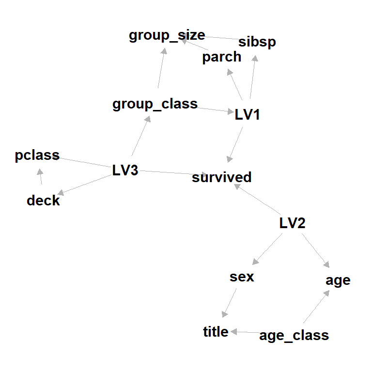

````markdown
```{r}
#| fig.width: 4
#| fig.height: 4
#| label: fig-bn-final
#| fig-cap: "Bayesian Network (FINAL)."
plot_bn(titanic_bn_final, "gem")
```
````

# Synthetic data

Bayesian Networks can be used to generate synthetic data that replicate the statistical properties of the data used to train the network. The synthetic data could then be used in training regression or classification models with the original data used for model validation.

````markdown
```{targets c_titanic_synthetic}
#| label: c_titanic_synthetic
#| tar_simple: true
#| tar_interactive: false
#| output: false

tar_target(c_titanic_synthetic, {
  bnlearn::rbn(titanic_bn_final,
               n = 10000)
})
```
````

Build the synthetic data `c_titanic_synthetic` generated from the final Bayesian Network `titanic_bn_final`.

````markdown
```{r}
#| output: false
#| message: false
#| error: false
if (length(tar_outdated()) > 0) {
  tar_make()
}
tar_load(c_titanic_synthetic)
```
````

# Conclusion

Bayesian Networks were used to explore the Titanic data from the Kaggle Titanic competition. A “final” Bayesian Network was constructed that included three unobserved features (latent variables) that directly effect survival. Latent Variable 1 is connected to survived, parch, sibsp, and group_class and represents group composition (family). Latent Variable 2 is connected to survived, age, age_class, and sex and represents individual characteristics. Latent Variable 3 is connected to survived, deck, passenger class, and group_class and represents the proximity of the passengers cabin to the life boats. The three latent variables account for the relationships between the observed variables and directly effect survival.

Further processing of the ticket variable could be done to better express the composition of the ticket. A group classification could be added to help identify observations that are mother-child, brother-brother, brother-sister, sister-sister, mother-father-2*child, mother-father-3*child, mother-father-4*child, group-of-friends, alone, and other. The number of group members that survived could also be added but will need to consider missing survival status.

A synthetic data set was generated from the “final” Bayesian Network which can be used for future classification modelling. The synthetic data will need to be validated to check that the statistics of the original data is replicated. The synthetic data may need to be regenerated to produce a balanced data set for classification modelling.

## References

Allaire, JJ. 2022. *Quarto: R Interface to ’Quarto’ Markdown Publishing System*. https://CRAN.R-project.org/package=quarto.

Arnold, Jeffrey B. 2021. *Ggthemes: Extra Themes, Scales and Geoms for ’Ggplot2’*. https://CRAN.R-project.org/package=ggthemes.

Arya, Sunil, David Mount, Samuel E. Kemp, and Gregory Jefferis. 2019. *RANN: Fast Nearest Neighbour Search (Wraps ANN Library) Using L2 Metric*. https://CRAN.R-project.org/package=RANN.

Barrett, Malcolm. 2023. *Ggdag: Analyze and Create Elegant Directed Acyclic Graphs*. https://CRAN.R-project.org/package=ggdag.

Grassi, Mario, Fernando Palluzzi, and Barbara Tarantino. 2023. *SEMgraph: Network Analysis and Causal Inference Through Structural Equation Modeling*. https://CRAN.R-project.org/package=SEMgraph.

Honaker, James, Gary King, and Matthew Blackwell. 2011. “Amelia II: A Program for Missing Data.” *Journal of Statistical Software* 45 (7): 1–47. https://doi.org/10.18637/jss.v045.i07.

Jeppson, Haley, Heike Hofmann, and Di Cook. 2021. *Ggmosaic: Mosaic Plots in the ’Ggplot2’ Framework*. https://CRAN.R-project.org/package=ggmosaic.

Landau, William Michael. 2021. “The Targets r Package: A Dynamic Make-Like Function-Oriented Pipeline Toolkit for Reproducibility and High-Performance Computing.” *Journal of Open Source Software* 6 (57): 2959. https://doi.org/10.21105/joss.02959.

Pedersen, Thomas Lin. 2022. *Patchwork: The Composer of Plots*. https://CRAN.R-project.org/package=patchwork.

R Core Team. 2023. *R: A Language and Environment for Statistical Computing*. Vienna, Austria: R Foundation for Statistical Computing. https://www.R-project.org/.

Scutari, Marco. 2010. “Learning Bayesian Networks with the bnlearn R Package.” *Journal of Statistical Software* 35 (3): 1–22. https://doi.org/10.18637/jss.v035.i03.

Wickham, Hadley, Mara Averick, Jennifer Bryan, Winston Chang, Lucy D’Agostino McGowan, Romain François, Garrett Grolemund, et al. 2019. “Welcome to the tidyverse.” *Journal of Open Source Software* 4 (43): 1686. https://doi.org/10.21105/joss.01686.

Xie, Yihui. 2023. *Knitr: A General-Purpose Package for Dynamic Report Generation in r*. https://yihui.org/knitr/.